# Project_HDS5330 (3)

```python
# modules
import pandas as pd
import numpy as np
from matplotlib import pyplot as plt
import seaborn as sns
```

```python
# data
df_alzr = pd.read_csv('/content/alzheimers_disease_data.csv')
df_alzr.head()
```

|  | PatientID | Age | Gender | Ethnicity | EducationLevel | BMI | Smoking | AlcoholConsumption | PhysicalActivity | DietQuality | ... | MemoryComplaints | BehavioralProblems | ADL | Confusion | Disorientation | PersonalityChanges | DifficultyCompletingTasks | Forgetfulness | Diagnosis | DoctorInCharge |
| --- | --- | --- | --- | --- | --- | --- | --- | --- | --- | --- | --- | --- | --- | --- | --- | --- | --- | --- | --- | --- | --- |
| 0 | 4751 | 73 | 0 | 0 | 2 | 22.927749 | 0 | 13.297218 | 6.327112 | 1.347214 | ... | 0 | 0 | 1.725883 | 0 | 0 | 0 | 1 | 0 | 0 | XXXConfid |
| 1 | 4752 | 89 | 0 | 0 | 0 | 26.827681 | 0 | 4.542524 | 7.619885 | 0.518767 | ... | 0 | 0 | 2.592424 | 0 | 0 | 0 | 0 | 1 | 0 | XXXConfid |
| 2 | 4753 | 73 | 0 | 3 | 1 | 17.795882 | 0 | 19.555085 | 7.844988 | 1.826335 | ... | 0 | 0 | 7.119548 | 0 | 1 | 0 | 1 | 0 | 0 | XXXConfid |
| 3 | 4754 | 74 | 1 | 0 | 1 | 33.800817 | 1 | 12.209266 | 8.428001 | 7.435604 | ... | 0 | 1 | 6.481226 | 0 | 0 | 0 | 0 | 0 | 0 | XXXConfid |
| 4 | 4755 | 89 | 0 | 0 | 0 | 20.716974 | 0 | 18.454356 | 6.310461 | 0.795498 | ... | 0 | 0 | 0.014691 | 0 | 0 | 1 | 1 | 0 | 0 | XXXConfid |

5 rows × 35 columns

```python
df_alzr = df_alzr.drop(['PatientID', 'DoctorInCharge'], axis=1)
df_alzr.head()
```

|  | Age | Gender | Ethnicity | EducationLevel | BMI | Smoking | AlcoholConsumption | PhysicalActivity | DietQuality | SleepQuality | ... | FunctionalAssessment | MemoryComplaints | BehavioralProblems | ADL | Confusion | Disorientation | PersonalityChanges | DifficultyCompletingTasks | Forgetfulness | Diagnosis |
| --- | --- | --- | --- | --- | --- | --- | --- | --- | --- | --- | --- | --- | --- | --- | --- | --- | --- | --- | --- | --- | --- |
| 0 | 73 | 0 | 0 | 2 | 22.927749 | 0 | 13.297218 | 6.327112 | 1.347214 | 9.025679 | ... | 6.518877 | 0 | 0 | 1.725883 | 0 | 0 | 0 | 1 | 0 | 0 |
| 1 | 89 | 0 | 0 | 0 | 26.827681 | 0 | 4.542524 | 7.619885 | 0.518767 | 7.151293 | ... | 7.118696 | 0 | 0 | 2.592424 | 0 | 0 | 0 | 0 | 1 | 0 |
| 2 | 73 | 0 | 3 | 1 | 17.795882 | 0 | 19.555085 | 7.844988 | 1.826335 | 9.673574 | ... | 5.895077 | 0 | 0 | 7.119548 | 0 | 1 | 0 | 1 | 0 | 0 |
| 3 | 74 | 1 | 0 | 1 | 33.800817 | 1 | 12.209266 | 8.428001 | 7.435604 | 8.392554 | ... | 8.965106 | 0 | 1 | 6.481226 | 0 | 0 | 0 | 0 | 0 | 0 |
| 4 | 89 | 0 | 0 | 0 | 20.716974 | 0 | 18.454356 | 6.310461 | 0.795498 | 5.597238 | ... | 6.045039 | 0 | 0 | 0.014691 | 0 | 0 | 1 | 1 | 0 | 0 |

5 rows × 33 columns

As its was unable to determine the correlation using the scatter plot, we have created a heatmap to find the correlated features.

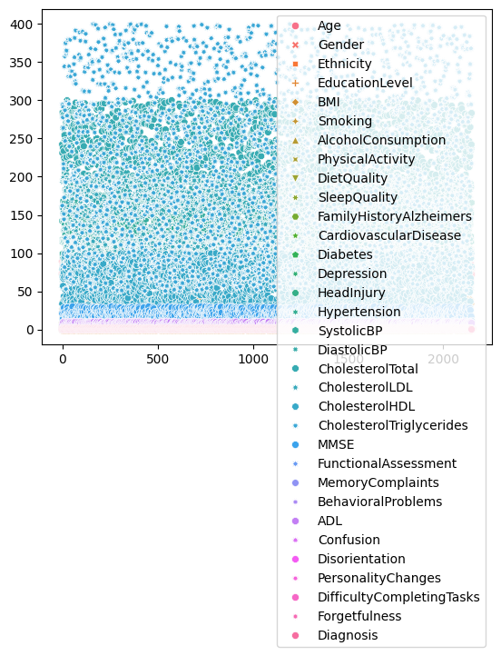

```python
sns.scatterplot(df_alzr)
```

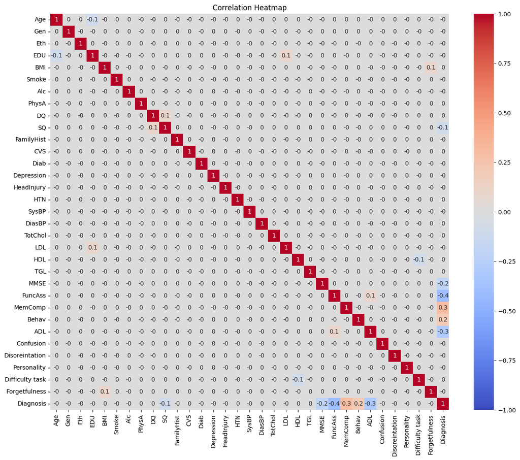

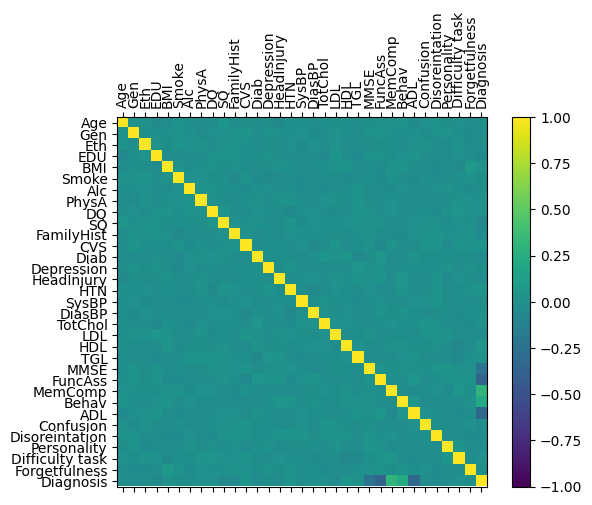

```python
import numpy as np

names = ['Age', 'Gen', 'Eth', 'EDU', 'BMI', 'Smoke', 'Alc', 'PhysA', 'DQ', 'SQ',
         'FamilyHist', 'CVS', 'Diab', 'Depression', 'HeadInjury', 'HTN', 'SysBP', 'DiasBP',
         'TotChol', 'LDL', 'HDL', 'TGL', 'MMSE', 'FuncAss', 'MemComp', 'Behav',
         'ADL', 'Confusion', 'Disoreintation', 'Personality', 'Difficulty task', 'Forgetfulness', 'Diagnosis'] # renaming the columns for clear view of plot
df_alzr.columns = names


cor = df_alzr.corr()

correlation_matrix = df_alzr.corr().round(1)

# Creating the heatmap
plt.figure(figsize=(15, 12))
sns.heatmap(correlation_matrix, vmin=-1, vmax=1, cmap="coolwarm", annot=True, xticklabels=names, yticklabels=names)
plt.title('Correlation Heatmap')
plt.show()

fig = plt.figure()
ax = fig.add_subplot(111)
cax = ax.matshow(cor, vmin=-1, vmax=1)
fig.colorbar(cax)

# Setting ticks and labels
ticks = np.arange(0, len(names), 1)
ax.set_xticks(ticks)
ax.set_yticks(ticks)
ax.set_xticklabels(names, rotation=90)
ax.set_yticklabels(names)

# Display the plot
plt.show()
```

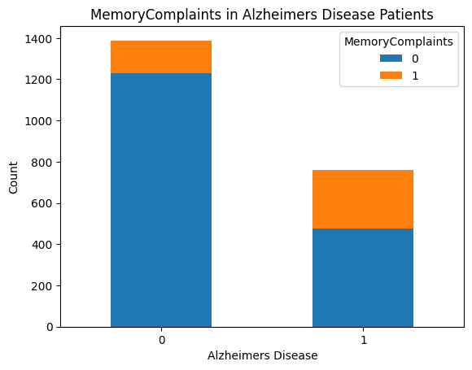

```python
Diagnosis_by_Memory = df_alzr.groupby(['Diagnosis', 'MemComp']).size().unstack()

# Plotting the bar plot
Diagnosis_by_Memory.plot(kind='bar', stacked=True)  # Set stacked=True if you want stacked bars

plt.title('MemoryComplaints in Alzheimers Disease Patients')
plt.xlabel('Alzheimers Disease')
plt.ylabel('Count')
plt.xticks(rotation=1)  # Rotate x labels for better visibility
plt.legend(title='MemoryComplaints', loc='upper right')
plt.show()
```

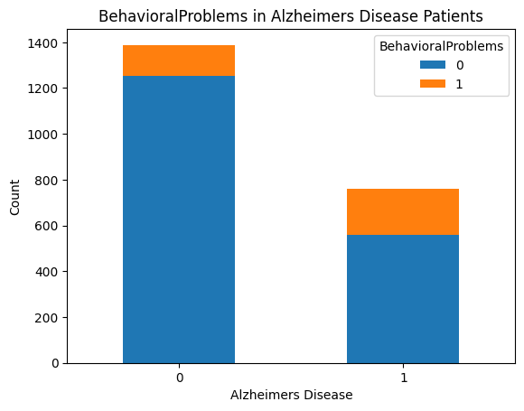

```python
Diagnosis_by_Behavioralproblems = df_alzr.groupby(['Diagnosis', 'Behav']).size().unstack()

# Plotting the bar plot
Diagnosis_by_Behavioralproblems.plot(kind='bar', stacked=True)  # Set stacked=True if you want stacked bars

plt.title('BehavioralProblems in Alzheimers Disease Patients')
plt.xlabel('Alzheimers Disease')
plt.ylabel('Count')
plt.xticks(rotation=1)  # Rotate x labels for better visibility
plt.legend(title='BehavioralProblems', loc='upper right')
plt.show()
```

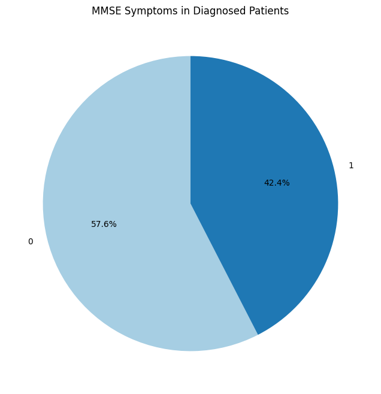

```python
diagnosis_MMSE = df_alzr.groupby('Diagnosis')['MMSE'].mean().reset_index()

# Create a pie chart
plt.figure(figsize=(8, 8))
plt.pie(diagnosis_MMSE['MMSE'], labels=diagnosis_MMSE['Diagnosis'], autopct='%1.1f%%', startangle=90, colors=plt.cm.Paired.colors)
plt.title('MMSE Symptoms in Diagnosed Patients')
plt.show()
```

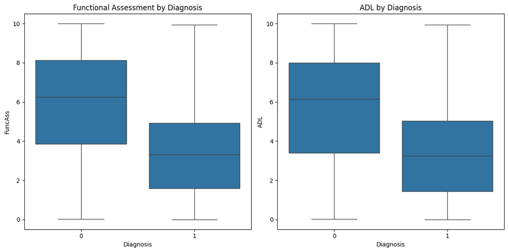

```python
fig, axes = plt.subplots(1, 2, figsize=(12, 6))

# Boxplot for FunctionalAssessment by Diagnosis
sns.boxplot(x='Diagnosis', y='FuncAss', data=df_alzr, ax=axes[0])
axes[0].set_title('Functional Assessment by Diagnosis')

# Boxplot for ADL by Diagnosis
sns.boxplot(x='Diagnosis', y='ADL', data=df_alzr, ax=axes[1])
axes[1].set_title('ADL by Diagnosis')

plt.tight_layout()
plt.show()
```

From the boxplots, it was observed that for cases where Alzheimer's diagnosis occurred have lesser values of Functional assessment values and lesser values of ADL, indicating that lesser values of these features are at more risk of Alzheimer's disease.

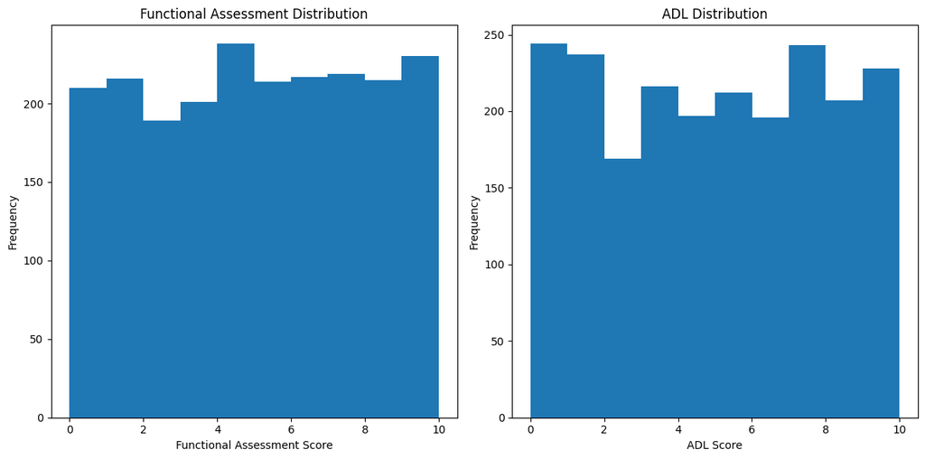

```python
fig, axes = plt.subplots(1, 2, figsize=(12, 6))

# Histogram for FunctionalAssessment
df_alzr['FuncAss'].plot.hist(bins=10, ax=axes[0])
axes[0].set_title('Functional Assessment Distribution')
axes[0].set_xlabel('Functional Assessment Score')
axes[0].set_ylabel('Frequency')

# Histogram for ADL
df_alzr['ADL'].plot.hist(bins=10, ax=axes[1])
axes[1].set_title('ADL Distribution')
axes[1].set_xlabel('ADL Score')
axes[1].set_ylabel('Frequency')

plt.tight_layout()
plt.show()
```

As observed earlier, the two graphs shows almost uniform distribution values of FunctionalAssesment and ADL score.

## **REGRESSION**

Linear Regression:

Since the outcome or target variable is a binary variable, the linear regression is not performed and the linear regression equation is not calculated. Hence, Logistic regression model has been built for the prediction of Alzheimer's disease.

```python
# Logistic Regression Model

from sklearn.linear_model import LogisticRegression
from sklearn.metrics import classification_report, confusion_matrix
x=df_alzr[['MMSE', 'MemComp', 'Behav']]
y=df_alzr['Diagnosis']
model = LogisticRegression(solver='liblinear',C=10,random_state=0) # define model
model.fit(x,y)
# evaluate the model
p_pred=model.predict_proba(x)
y_pred=model.predict(x)
scor=model.score(x,y)
conf_m=confusion_matrix(y,y_pred)
print(scor)
print(conf_m)
```

```
0.7566309911586785
[[1262  127]
 [ 396  364]]
```

From the results, it can be observed that the model correctly predicts the Alzheimer’s diagnosis of about 75.6%. The confusion matrix results reveal that the model correctly predicted the positive class 364 times and 1262 times the negative class. In addition, the model incorrectly predicted the true false positive and dales negative 127 and 396 times respectively.

```python
# Model Evaluation
print(classification_report(y,model.predict(x)))
```

```
              precision    recall  f1-score   support

           0       0.76      0.91      0.83      1389
           1       0.74      0.48      0.58       760

    accuracy                           0.76      2149
   macro avg       0.75      0.69      0.71      2149
weighted avg       0.75      0.76      0.74      2149
```

```python
#from google.colab import drive
#drive.mount('/content/drive')
```

Based on the results, the model's precision for class 0 (no diagnosis) is 76% and for class 1 (diagnosis) is 74%. The model identified 91% of the true negative class (class 0), whereas it has identified only 47% of the true positive cases (class 1). The F1 scores show that the model did great in predicting the patients who were not diagnosed with Alzheimer’s than with the people with actual diagnosis (i.e., 83% and 58% respectively). Overall, the model performed well in predicting the negative class with high recall (91%) and a good F1-score (83%). However, the performance for the positive class was low, indicating that it has missed a significant number of the diagnosed cases.

```python
# KNN Graph
x = df_alzr[['MMSE', 'MemComp']]
y = df_alzr['Diagnosis']
```

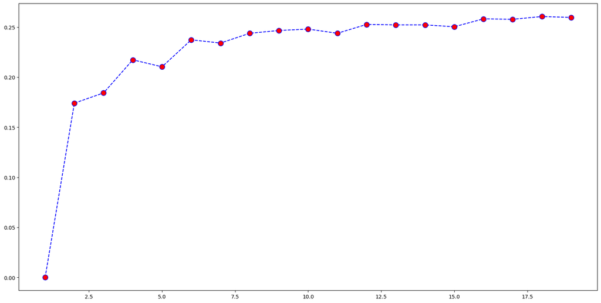

```python
import numpy as np
from sklearn.neighbors import KNeighborsClassifier
import matplotlib.pyplot as plt
SSE=[]
for k in range(1,20):
    knn=KNeighborsClassifier(n_neighbors=k)
    knn.fit(x,y)
    pred_i=knn.predict(x)
    SSE.append(np.mean(pred_i != y))
plt.figure(figsize=(20,10))
plt.plot(range(1,20),SSE,color='b',linestyle='dashed',marker='o',markerfacecolor='r',markersize=10)
plt.show()
```

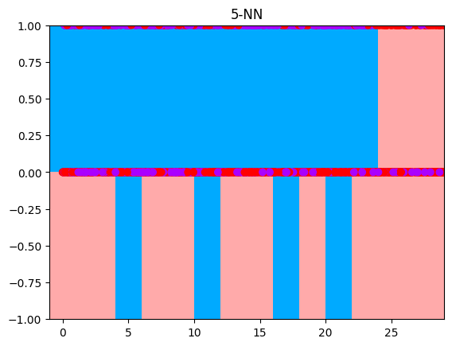

```python
from matplotlib.colors import ListedColormap
n_neighbors=3
X=x.values[:,0:2]
h=2
clf=KNeighborsClassifier(n_neighbors,weights='uniform')
clf.fit(X,y)
x_min, x_max=X[:,0].min()-1, X[:,0].max()+1  # x axis
y_min, y_max=X[:,1].min()-1, X[:,1].max()+1  # y axis
xx,yy=np.meshgrid(np.arange(x_min,x_max,h),np.arange(y_min,y_max,h)) # grids
cmap_l =ListedColormap(['#FFAAAA','#AAFFAA','#00AAFF']) # predicted
cmap_d =ListedColormap(['#FF0000','#00FF00','#AA00FF']) # actual

Z= clf.predict(np.c_[xx.ravel(),yy.ravel()])
Z=Z.reshape(xx.shape)
plt.figure()
plt.pcolormesh(xx,yy,Z,cmap=cmap_l) # predicted values on back
plt.scatter(X[:,0],X[:,1],c=y,cmap=cmap_d) # actual values
plt.xlim(xx.min(),xx.max())
plt.ylim(yy.min(),yy.max())
plt.title("5-NN")
plt.show()
```

```python
from sklearn.model_selection import train_test_split
X_train, X_test, y_train, y_test = train_test_split(X, y, test_size = 0.2)

train_accuracy = clf.score(X_train, y_train)
test_accuracy = clf.score(X_test, y_test)
print(train_accuracy)
print(test_accuracy)
```

```
0.8155904595695171
0.8162790697674419
```

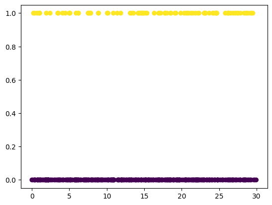

```python
from sklearn.naive_bayes import GaussianNB
from sklearn.model_selection import train_test_split
X_train, X_test, y_train, y_test=train_test_split(X,y,test_size=0.2, random_state=0)
clf=GaussianNB()
clf.fit(X_train,y_train)

y_pred=clf.predict(X_test)

plt.scatter(X_test[:,0],X_test[:,1], c=y_pred, cmap='viridis')
plt.show()
```

```python
train_accuracy = clf.score(X_train, y_train)
test_accuracy = clf.score(X_test, y_test)
print(train_accuracy)
print(test_accuracy)
```

```
0.7079697498545666
0.6906976744186046
```

```python
x = df_alzr[['MMSE', 'MemComp']]
y = df_alzr['Diagnosis']
```

```python
# define- fit - predict - find the accuracy of models
from sklearn import svm
from sklearn.metrics import accuracy_score
# linear kernel
svc=svm.SVC(kernel='linear', C=1).fit(x,y)
svc_pred=svc.predict(x)
print('svc accuracy',accuracy_score(y,svc_pred)*100)
# linear svm
lin_svc=svm.LinearSVC(C=1).fit(x,y)
lsvc_pred=lin_svc.predict(x)
print('linear svc accuracy',accuracy_score(y,lsvc_pred)*100)
# rbf kernel
rbf_svc=svm.SVC(kernel='rbf', gamma=0.7, C=1).fit(x,y)
rsvc_pred=rbf_svc.predict(x)
print('rbf accuracy',accuracy_score(y,rsvc_pred)*100)
# poly kernel, degree 3 ax^3+bx^2+cx+d
poly_svc=svm.SVC(kernel='poly', degree=3, C=1).fit(x,y)
psvc_pred=poly_svc.predict(x)
print('poly accuracy',accuracy_score(y,psvc_pred)*100)
```

```
svc accuracy 70.45137273150303
linear svc accuracy 73.05723592368544
rbf accuracy 73.98790134946486
poly accuracy 64.63471382038158
```

```python
x = df_alzr[['MMSE', 'MemComp']].to_numpy()
y = df_alzr['Diagnosis']
```

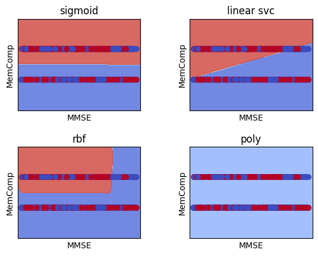

```python
h=0.02
x_min, x_max = x[:,0].min()-1, x[:,0].max()+1 # MMSE over x axis
y_min, y_max = x[:,1].min()-1, x[:,1].max()+1 # Memory complaints over y axis
xx, yy=np.meshgrid(np.arange(x_min,x_max,h),np.arange(y_min,y_max,h))

titles=['sigmoid','linear svc','rbf','poly']

for i, clf in enumerate((svc, lin_svc, rbf_svc, poly_svc)):
    # create 4 subplots
    plt.subplot(2,2,i+1)
    plt.subplots_adjust(wspace=0.4,hspace=0.4)

    # predict destinations based on num_code and price
    Z=clf.predict(np.c_[xx.ravel(),yy.ravel()])
    Z=Z.reshape(xx.shape)

    # plot actual and predicted values
    plt.contourf(xx,yy,Z,cmap=plt.cm.coolwarm, alpha=0.8)
    plt.scatter(x[:,0],x[:,1], c=y, cmap=plt.cm.coolwarm)

    # modify the graphs by adding labels, titles, ...
    plt.xlabel('MMSE')
    plt.ylabel('MemComp')
    plt.xlim(xx.min(),xx.max())
    plt.ylim(yy.min(),yy.max())
    plt.xticks(())
    plt.yticks(())
    plt.title(titles[i])

plt.show()
```

```python
from sklearn.model_selection import train_test_split
from sklearn.ensemble import RandomForestClassifier
```

```python
x = df_alzr[['MMSE', 'MemComp']].to_numpy()
y = df_alzr['Diagnosis']
```

```python
# split data to tran and test
X_train, X_test, y_train, y_test=train_test_split(X,y, test_size=0.3)
# define the model, fit the model
clf=RandomForestClassifier(n_estimators=50)
clf.fit(X_train, y_train)
RandomForestClassifier(n_estimators=50)
y_pred=clf.predict(X_test)

from sklearn.metrics import confusion_matrix, accuracy_score, classification_report
CM=confusion_matrix(y_pred,y_test)
print(CM)
AS=accuracy_score(y_pred,y_test)
print(AS)
CR=classification_report(y_pred,y_test)
print(CR)
```

```
[[286 121]
 [115 123]]
0.6341085271317829
              precision    recall  f1-score   support

           0       0.71      0.70      0.71       407
           1       0.50      0.52      0.51       238

    accuracy                           0.63       645
   macro avg       0.61      0.61      0.61       645
weighted avg       0.64      0.63      0.64       645
```

The model achieves an overall accuracy of 63.41%, indicating it correctly predicts the target variable roughly two-thirds of the time.

The precision for Class 0 (negative diagnosis) is 71%, with a recall of 70%, resulting in an F1-score of 0.71. This indicates that the model is relatively effective at identifying negatives. However, for Class 1 (positive diagnosis), the precision and recall are both lower, around 50%, leading to an F1-score of 0.51. The disparity suggests that the model struggles with identifying true positives.

Out of 645 instances in the test dataset, the model correctly predicted 63% of all instances, indicating moderate overall performance. The Macro Average(61%) reflects the unweighted average of precision, recall, and F1-score across classes, showing balanced performance for each class regardless of size. Weighted Average (nearly 64%) accounts for class distribution, slightly favoring the larger class (class 0) due to its higher representation.

```python
!conda info --envs
%pip install graphviz
from sklearn.tree import export_graphviz
import graphviz
```

```
/bin/bash: line 1: conda: command not found
```

```python
# Make a Random Forest
rf=RandomForestClassifier(n_estimators=1)
rf.fit(X_train,y_train)
len(rf.estimators_)
```

```
1
```

This confirms that the Random Forest contains only 1 decision tree

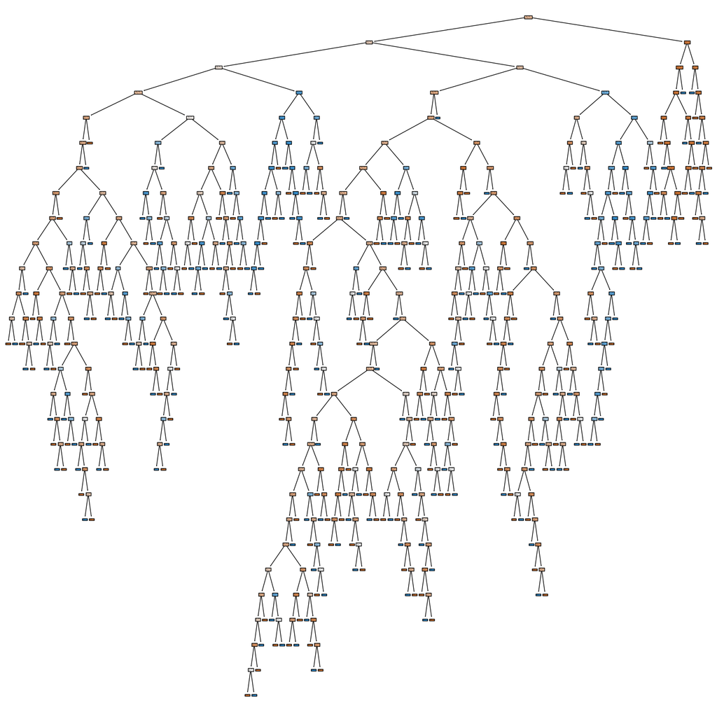

```python
from sklearn import tree
x = df_alzr[['MMSE', 'MemComp']].to_numpy()
y = df_alzr['Diagnosis']
plt.figure(figsize=(20,20))
_=tree.plot_tree(rf.estimators_[0], filled=True)
```

The tree plot is highly complex and deeply branched, reflecting the complicated nature of the data. However, the extensive branching makes interpreting or extracting meaningful insights challenging.